# Gas Fees Data Acquisition and Signal Analysis

## Decomposed Phase Shifts Overlay

To understand which signals may be leading or lagging indicators, we will overlay the fourier decomposed components, in pairs, for analysis.

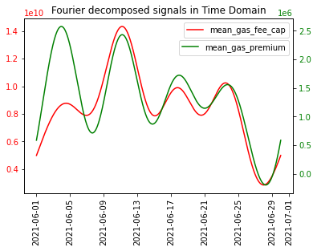

```python
phase_shift_overlay(derived_gas_outputs.timestamp,mean_gas_fee_cap_decomposed,mean_gas_premium_decomposed,
                    'mean_gas_fee_cap','mean_gas_premium')
```

Gas premium appears to be a leading indicator for gas fee cap. There is no phase shift (peak to peak distances line up).

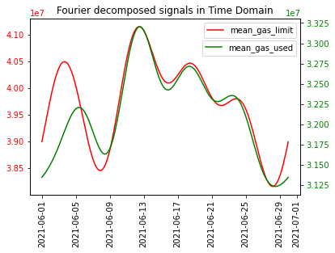

```python
phase_shift_overlay(derived_gas_outputs.timestamp,mean_gas_limit_decomposed,mean_gas_used_decomposed,
                   'mean_gas_limit','mean_gas_used')
```

Gas limit, at times, appears to be a slight leading indicator.

```python
# phase_shift_overlay(derived_gas_outputs.timestamp,mean_parent_base_fee_decomposed,mean_base_fee_burn_decomposed,
#                    'mean_parent_base_fee','mean_base_fee')
```

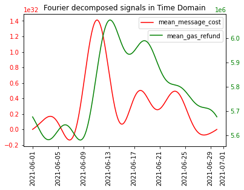

```python
phase_shift_overlay(derived_gas_outputs.timestamp,mean_message_cost_decomposed,mean_gas_refund_decomposed,
                   'mean_message_cost','mean_gas_refund')
```

Message cost, at times, appears to be a slight leading indicator.

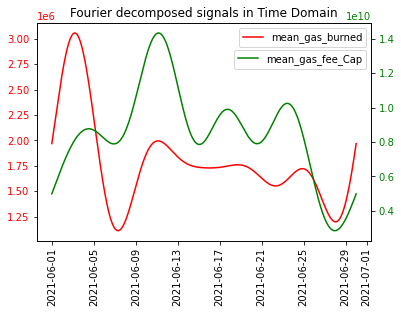

```python
phase_shift_overlay(derived_gas_outputs.timestamp,mean_gas_burned_decomposed,mean_gas_fee_cap_decomposed,
                   'mean_gas_burned','mean_gas_fee_Cap')
```

Gas burned appears to be a direct leading indicator. No phase shift present

Below we will normalize the signals by their individual max peaks so we can plot on one graph. We will use Matplotlib instead of Plotly due to the fact that Matplotlib handles complex numbers better.

```python
# normalize peaks
mean_gas_fee_cap_decomposed_normalized = peak_normalization(mean_gas_fee_cap_decomposed)
mean_gas_premium_decomposed_normalized = peak_normalization(mean_gas_premium_decomposed)
mean_gas_limit_decomposed_normalized = peak_normalization(mean_gas_limit_decomposed)
mean_gas_used_decomposed_normalized = peak_normalization(mean_gas_used_decomposed)
mean_base_fee_burn_decomposed_normalized = peak_normalization(mean_base_fee_burn_decomposed)
mean_message_cost_decomposed = peak_normalization(mean_message_cost_decomposed)
mean_gas_refund_decomposed = peak_normalization(mean_gas_refund_decomposed)
mean_gas_burned_decomposed = peak_normalization(mean_gas_burned_decomposed)
mean_gas_fee_cap_decomposed = peak_normalization(mean_gas_fee_cap_decomposed)
```

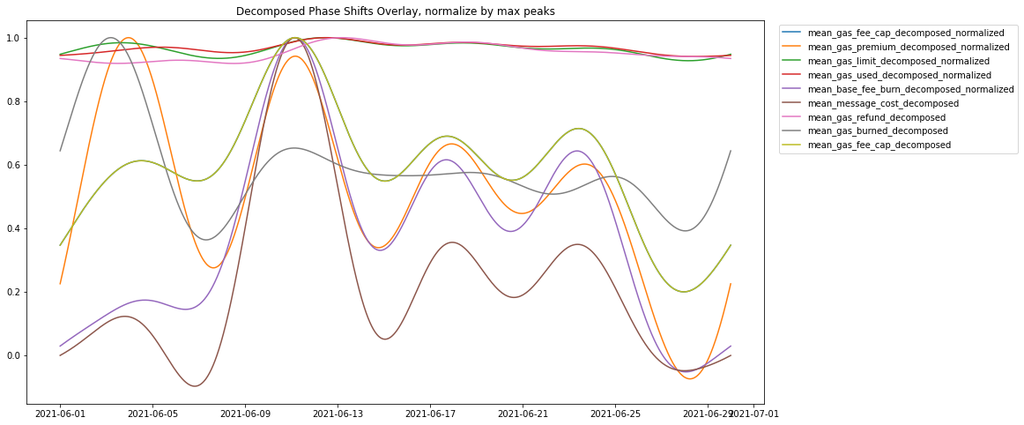

```python
timestamps = derived_gas_outputs.timestamp

plt.figure(figsize=(15, 8))
plt.plot(timestamps,mean_gas_fee_cap_decomposed_normalized,label = 'mean_gas_fee_cap_decomposed_normalized')
plt.plot(timestamps,mean_gas_premium_decomposed_normalized, label ='mean_gas_premium_decomposed_normalized')
plt.plot(timestamps,mean_gas_limit_decomposed_normalized, label ='mean_gas_limit_decomposed_normalized')
plt.plot(timestamps,mean_gas_used_decomposed_normalized, label ='mean_gas_used_decomposed_normalized')
plt.plot(timestamps,mean_base_fee_burn_decomposed_normalized, label ='mean_base_fee_burn_decomposed_normalized')
plt.plot(timestamps,mean_message_cost_decomposed, label ='mean_message_cost_decomposed')
plt.plot(timestamps,mean_gas_refund_decomposed, label ='mean_gas_refund_decomposed')
plt.plot(timestamps,mean_gas_burned_decomposed, label ='mean_gas_burned_decomposed')
plt.plot(timestamps,mean_gas_fee_cap_decomposed, label ='mean_gas_fee_cap_decomposed')
plt.legend(bbox_to_anchor=(1.35, 1), loc='upper right', ncol=1)
plt.title('Decomposed Phase Shifts Overlay, normalize by max peaks')
```

## Conclusion

In this notebook, we obtained the main data table for Filecoin's gas economy, downloaded minute aggregated data for June, and performed Fourier Analysis on the data. Which variables are leading and lagging indicators provides us key information as we begin to build an intuition on the Filecoin system.